# 02_Supervised-Learning

## Project 2 - Supervised Learning

## Author - [Shekar Roy](https://github.com/shekarroy15)

### Part 1 / 2

• **DOMAIN**: Healthcare

• **CONTEXT**: Medical research university X is undergoing a deep research on patients with certain conditions. University has an internal AI team. Due to confidentiality the patient’s details and the conditions are masked by the client by providing different datasets to the AI team for developing a AIML model which can predict the condition of the patient depending on the received test results.

• **DATA DESCRIPTION**: The data consists of biomechanics features of the patients according to their current conditions. Each patient is represented in the data set by six biomechanics attributes derived from the shape and orientation of the condition to their body part.

1. P_incidence
2. P_tilt
3. L_angle
4. S_slope
5. P_radius
6. S_degree
7. Class

• **Learning Outcomes**

- Exploratory Data Analysis
- Preparing the data to train a model
- Training and making predictions using a classification model
- Model evaluation

```python
## Importing Libraries

import numpy as np
import pandas as pd
import seaborn as sns
import matplotlib.pyplot as plt
%matplotlib inline
from sklearn.preprocessing import StandardScaler
from sklearn.model_selection import train_test_split
from sklearn.neighbors import KNeighborsClassifier
from sklearn.linear_model import LogisticRegression
from sklearn.metrics import confusion_matrix
```

```python
# Reading 1 csv file

df1 = pd.read_csv('Part1 - Normal.csv')
df1.shape
```

```
(100, 7)
```

```python
# Reading 2 csv file
df2 = pd.read_csv('Part1 - Type_H.csv')
df2.shape
```

```
(60, 7)
```

```python
# Reading 3rd csv file
df3 = pd.read_csv('Part1 - Type_S.csv')
df3.shape
```

```
(150, 7)
```

#### Joining the dataframes to one single dataframe

```python
frames = [df1, df2, df3]
result = pd.concat(frames)
result
```

|  | P_incidence | P_tilt | L_angle | S_slope | P_radius | S_Degree | Class |
| --- | --- | --- | --- | --- | --- | --- | --- |
| 0 | 38.505273 | 16.964297 | 35.112814 | 21.540976 | 127.632875 | 7.986683 | Normal |
| 1 | 54.920858 | 18.968430 | 51.601455 | 35.952428 | 125.846646 | 2.001642 | Normal |
| 2 | 44.362490 | 8.945435 | 46.902096 | 35.417055 | 129.220682 | 4.994195 | Normal |
| 3 | 48.318931 | 17.452121 | 48.000000 | 30.866809 | 128.980308 | -0.910941 | Normal |
| 4 | 45.701789 | 10.659859 | 42.577846 | 35.041929 | 130.178314 | -3.388910 | Normal |
| ... | ... | ... | ... | ... | ... | ... | ... |
| 145 | 80.111572 | 33.942432 | 85.101608 | 46.169139 | 125.593624 | 100.292107 | Type_S |
| 146 | 95.480229 | 46.550053 | 59.000000 | 48.930176 | 96.683903 | 77.283072 | Type_S |
| 147 | 74.094731 | 18.823727 | 76.032156 | 55.271004 | 128.405731 | 73.388216 | Type_S |
| 148 | 87.679087 | 20.365613 | 93.822416 | 67.313473 | 120.944829 | 76.730629 | Type_S |
| 149 | 48.259920 | 16.417462 | 36.329137 | 31.842457 | 94.882336 | 28.343799 | Type_S |

310 rows × 7 columns

#### final dataset consists of 310 rows and 7 columns , as seen above!

```python
result.describe()
```

|  | P_incidence | P_tilt | L_angle | S_slope | P_radius | S_Degree |
| --- | --- | --- | --- | --- | --- | --- |
| count | 310.000000 | 310.000000 | 310.000000 | 310.000000 | 310.000000 | 310.000000 |
| mean | 60.496653 | 17.542822 | 51.930930 | 42.953831 | 117.920655 | 26.296694 |
| std | 17.236520 | 10.008330 | 18.554064 | 13.423102 | 13.317377 | 37.559027 |
| min | 26.147921 | -6.554948 | 14.000000 | 13.366931 | 70.082575 | -11.058179 |
| 25% | 46.430294 | 10.667069 | 37.000000 | 33.347122 | 110.709196 | 1.603727 |
| 50% | 58.691038 | 16.357689 | 49.562398 | 42.404912 | 118.268178 | 11.767934 |
| 75% | 72.877696 | 22.120395 | 63.000000 | 52.695888 | 125.467674 | 41.287352 |
| max | 129.834041 | 49.431864 | 125.742385 | 121.429566 | 163.071041 | 418.543082 |

```python
# Checking the datatype
result.dtypes
```

```
P_incidence    float64
P_tilt         float64
L_angle        float64
S_slope        float64
P_radius       float64
S_Degree       float64
Class           object
dtype: object
```

```python
# checking for null values
result.isna().sum()
```

```
P_incidence    0
P_tilt         0
L_angle        0
S_slope        0
P_radius       0
S_Degree       0
Class          0
dtype: int64
```

##### No Null values, great!

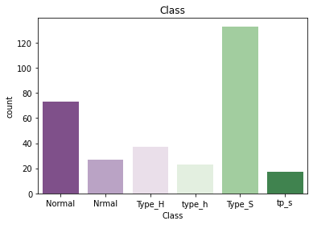

```python
# checking if the "Class" values are all same per nomenclature, if not treat them
sns.countplot(x="Class", data=result, palette="PRGn")
plt.title("Class")
plt.show()
```

```python
# need to get the values to reflect same definition, as of now there are 2 types of values of same type
result = result.replace(['Nrmal'], 'Normal')
result = result.replace(['type_h'], 'Type_H')
result = result.replace(['tp_s'], 'Type_S')
```

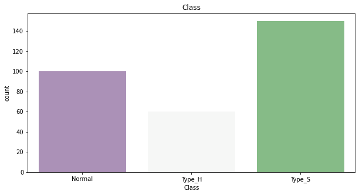

```python
# replotting the dataframe
plt.figure(figsize=(10,5))
sns.countplot(x="Class", data=result, palette="PRGn")
plt.title("Class")
plt.show()
```

### Segregate predictors vs target attributes, needed for boxplots

```python
X = result.drop(["Class"],axis=1)
y = result["Class"].values
```

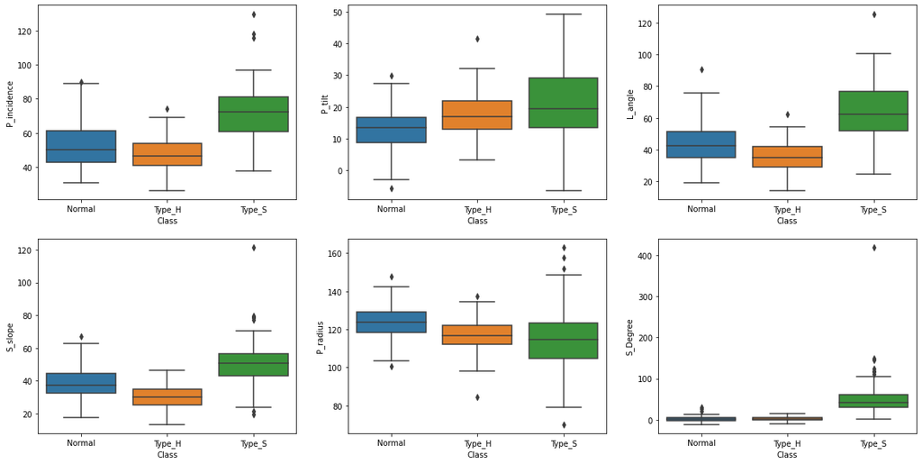

```python
#Create boxplot for each variable
plt.figure(figsize=(20,10))
for id, var in enumerate(X):
    plt.subplot(2,3,id+1)
    sns.boxplot(x='Class', y=var, data=result)
```

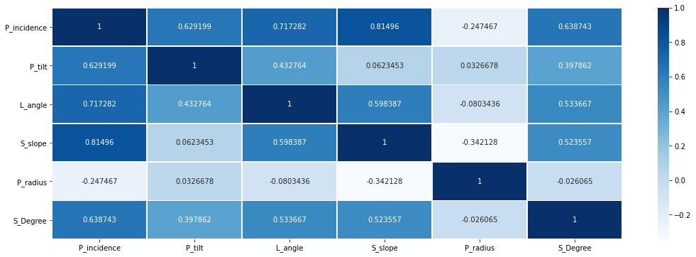

```python
# let's check the correlation using a heatmap, and computing the correlation b/w attributes
plt.figure(figsize = (18,6))
sns.heatmap(result.corr(), annot=True, cmap="Blues", linewidths=0.55, fmt= 'g');
```

#### HeatMap Inference - Putting aside the classes we try to see now the correlation between the various variables, to get an idea also on the link between one variable and another.

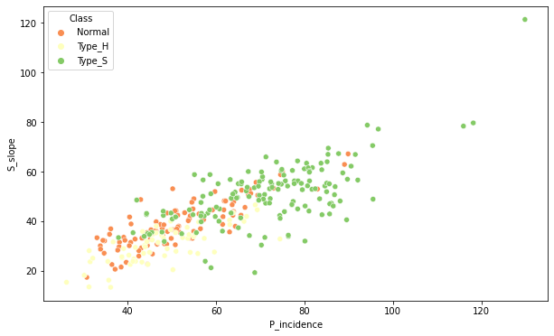

```python
# make a scatterplot to see the data distribution.

plt.figure(figsize=(10,6))
sns.scatterplot("P_incidence" , y="S_slope" , hue="Class" , palette="RdYlGn" , data=result);
```

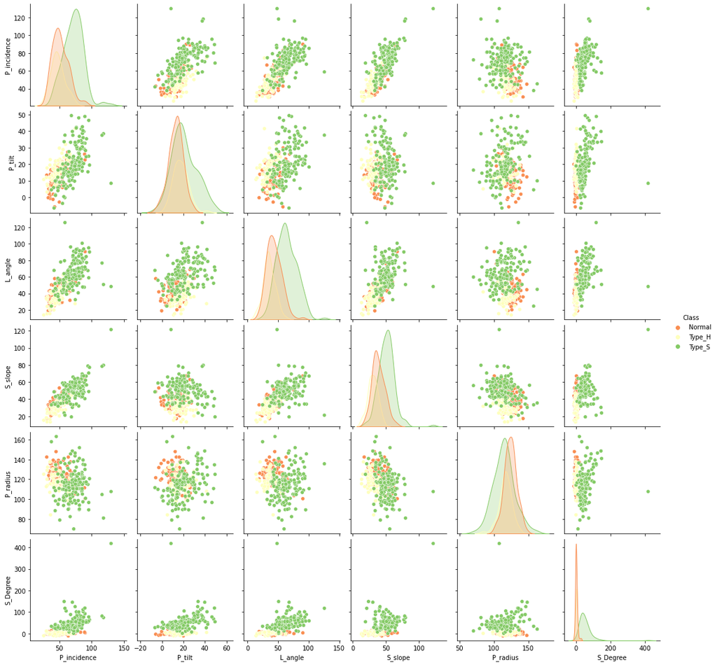

```python
sns.pairplot(result, hue="Class", palette="RdYlGn")
plt.show()
```

##### The following pairplot shows us graphically the mathematical model that binds the biomechanical variables:

### Normalizing the data now

```python
# I will use Standard Scaler for standardizing the data.
X_std=StandardScaler().fit_transform(X)
scaled_df = pd.DataFrame(X_std, columns=['P_incidence', 'P_tilt', 'L_angle','S_slope','P_radius','S_Degree'])
scaled_df.describe()
```

|  | P_incidence | P_tilt | L_angle | S_slope | P_radius | S_Degree |
| --- | --- | --- | --- | --- | --- | --- |
| count | 3.100000e+02 | 3.100000e+02 | 3.100000e+02 | 3.100000e+02 | 3.100000e+02 | 3.100000e+02 |
| mean | 8.702716e-17 | 2.326096e-16 | 1.980495e-16 | 5.121351e-17 | -6.274551e-16 | -8.156558e-17 |
| std | 1.001617e+00 | 1.001617e+00 | 1.001617e+00 | 1.001617e+00 | 1.001617e+00 | 1.001617e+00 |
| min | -1.996010e+00 | -2.411664e+00 | -2.047652e+00 | -2.207741e+00 | -3.597963e+00 | -9.961725e-01 |
| 25% | -8.173982e-01 | -6.881138e-01 | -8.060267e-01 | -7.168418e-01 | -5.423830e-01 | -6.585073e-01 |
| 50% | -1.049246e-01 | -1.186061e-01 | -1.278621e-01 | -4.095971e-02 | 2.613767e-02 | -3.874502e-01 |
| 75% | 7.194643e-01 | 4.581158e-01 | 5.975493e-01 | 7.269414e-01 | 5.676209e-01 | 3.997679e-01 |
| max | 4.029206e+00 | 3.191402e+00 | 3.984615e+00 | 5.855771e+00 | 3.395818e+00 | 1.046035e+01 |

##### graphical representation of how data was before standardization and is after standardization.

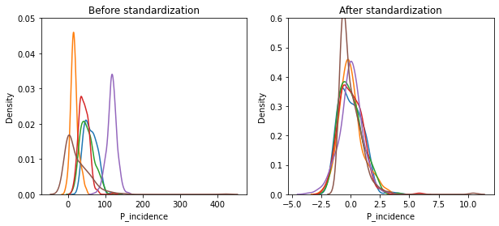

```python
fig, (ax1, ax2) = plt.subplots(ncols=2, figsize=(10, 4))

ax1.set_title('Before standardization')
sns.kdeplot(result['P_incidence'], ax=ax1)
sns.kdeplot(result['P_tilt'], ax=ax1)
sns.kdeplot(result['L_angle'], ax=ax1)
sns.kdeplot(result['S_slope'], ax=ax1)
sns.kdeplot(result['P_radius'], ax=ax1)
sns.kdeplot(result['S_Degree'], ax=ax1)
ax1.set_ylim(0,0.05)

ax2.set_title('After standardization')
sns.kdeplot(scaled_df['P_incidence'], ax=ax2)
sns.kdeplot(scaled_df['P_tilt'], ax=ax2)
sns.kdeplot(scaled_df['L_angle'], ax=ax2)
sns.kdeplot(scaled_df['S_slope'], ax=ax2)
sns.kdeplot(scaled_df['P_radius'], ax=ax2)
sns.kdeplot(scaled_df['S_Degree'], ax=ax2)
ax2.set_ylim(0,0.6)

plt.show()
```

##### As a rule of thumb, we should definately do scaling when the data is dealing with distances,

###### as we can see the plots were all over the place, using a scaling technique, we are able to see a much smoother dataframe that can now be used to train our models

### Perform Train_test_split method

```python
# no particular reason to choose random_state to 42. just a random decision

x_train,x_test,y_train,y_test = train_test_split(X,y,test_size=0.3,random_state=42)
print('X_train dim:', x_train.shape)
print('X_test dim:',x_test.shape)
```

```
X_train dim: (217, 6)
X_test dim: (93, 6)
```

#### Automate the task of finding best values of K for KNN.

```python
neig = np.arange(1, 25)
train_accuracy = []
test_accuracy = []
for i, k in enumerate(neig):
    knn = KNeighborsClassifier(n_neighbors=k)
    knn.fit(x_train,y_train)
    prediction_ = knn.predict(x_test)
    train_accuracy.append(knn.score(x_train, y_train))
    test_accuracy.append(knn.score(x_test, y_test))

print("Best accuracy is {} with K = {}".format(np.max(test_accuracy), 1 + test_accuracy.index(np.max(test_accuracy))))
```

```
Best accuracy is 0.8817204301075269 with K = 11
```

##### Trying different model types in automated fashion.

```python
models=[LogisticRegression(multi_class='multinomial',solver='newton-cg'),
        LogisticRegression(),
        KNeighborsClassifier(n_neighbors=3),
        KNeighborsClassifier(n_neighbors=8),
        KNeighborsClassifier(n_neighbors=11)]

classifier_comparison=pd.DataFrame(columns=['Classifier','train_score','test_score'])

for i in range(len(models)):
    models[i].fit(x_train,y_train)
    if i==0:
        classifier_comparison.loc[i,'Classifier']='MultinomialLogisticRegression'
        classifier_comparison.loc[i,'train_score']=models[i].score(x_train,y_train)
        classifier_comparison.loc[i,'test_score']=models[i].score(x_test,y_test)
    elif i==1:
        classifier_comparison.loc[i,'Classifier']='LogisticRegression'
        classifier_comparison.loc[i,'train_score']=models[i].score(x_train,y_train)
        classifier_comparison.loc[i,'test_score']=models[i].score(x_test,y_test)
    elif i==2:
        classifier_comparison.loc[i,'Classifier']='KNeignborsClassifier (k=3)'
        classifier_comparison.loc[i,'train_score']=models[i].score(x_train,y_train)
        classifier_comparison.loc[i,'test_score']=models[i].score(x_test,y_test)
    elif i==3:
        classifier_comparison.loc[i,'Classifier']='KNeignborsClassifier (k=8)'
        classifier_comparison.loc[i,'train_score']=models[i].score(x_train,y_train)
        classifier_comparison.loc[i,'test_score']=models[i].score(x_test,y_test)
    elif i==4:
        classifier_comparison.loc[i,'Classifier']='KNeignborsClassifier (k=11)'
        classifier_comparison.loc[i,'train_score']=models[i].score(x_train,y_train)
        classifier_comparison.loc[i,'test_score']=models[i].score(x_test,y_test)
    else:
        classifier_comparison.loc[i,'Classificatore']=models[i].__class__.__name__
        classifier_comparison.loc[i,'train_score']=models[i].score(x_train,y_train)
        classifier_comparison.loc[i,'test_score']=models[i].score(x_test,y_test)
classifier_comparison
```

|  | Classifier | train_score | test_score |
| --- | --- | --- | --- |
| 0 | MultinomialLogisticRegression | 0.866359 | 0.903226 |
| 1 | LogisticRegression | 0.857143 | 0.903226 |
| 2 | KNeignborsClassifier (k=3) | 0.912442 | 0.806452 |
| 3 | KNeignborsClassifier (k=8) | 0.847926 | 0.83871 |
| 4 | KNeignborsClassifier (k=11) | 0.843318 | 0.88172 |

### Confusion Matrix, Precision, Recall

Previously I evaluated my models using Accuracy metric. Now to measure the performance of the model I will use Precision and Recall, that I will derive from Confusion Matrix

```python
import itertools
def plot_confusion_matrix(cm, classes,normalize=False, cmap='Greens'):

    #This function prints and plots the confusion matrix.
   #Normalization can be applied by setting `normalize=True`.

    if normalize:
        cm = cm.astype('float') / cm.sum(axis=1)[:, np.newaxis]

    plt.imshow(cm, interpolation='nearest', cmap=cmap)

    plt.colorbar()
    tick_marks = np.arange(len(classes))
    plt.xticks(tick_marks, classes, rotation=45)
    plt.yticks(tick_marks, classes)
    fmt = '.2f' if normalize else 'd'
    thresh = cm.max() / 2.
    for i, j in itertools.product(range(cm.shape[0]), range(cm.shape[1])):
        plt.text(j, i, format(cm[i, j], fmt),
                 horizontalalignment="center",
                 color="white" if cm[i, j] > thresh else "black")

    plt.ylabel('True label')
    plt.xlabel('Predicted label')
    plt.tight_layout()
```

```python
from sklearn.model_selection import cross_val_score, cross_validate
from sklearn.model_selection import cross_val_score
scores = cross_val_score(LogisticRegression(multi_class='multinomial',solver='newton-cg'), X, y)
from sklearn.model_selection import cross_val_predict
y_predL = cross_val_predict(LogisticRegression(multi_class='multinomial',solver='newton-cg'), X, y)
conf_matL = confusion_matrix(y, y_predL)
```

[figure not shown]

```python
class_names=['Type_H','Normal','Type_S']
# Plot non-normalized confusion matrix
plt.figure()
plot_confusion_matrix(conf_matL, classes=class_names )
```

[figure not shown]

```python
# Plot normalized confusion matrix
plt.figure()
plot_confusion_matrix(conf_matL, classes=class_names, normalize=True )
plt.show()
```

```python
recall=np.diag(conf_matL)/np.sum(conf_matL,axis=1)
precision=np.diag(conf_matL)/np.sum(conf_matL,axis=0)

comparison=pd.DataFrame(index=['Type_H','Normal','Type_S'],columns=['Recall %','Precision %'])
comparison['Recall %']=recall*100
comparison['Precision %']=precision*100
comparison
```

[output not shown]

### Conclusions for project 1 / 2

##### However, I have found that patients labeled with the "Type_H" and "Normal" classes have similar characteristics and there is no clear division between the two classes, while patients labeled with the "Type_S" class are more separate than the other two classes. In general, for the analyzed dataset, the techniques used are quite efficient, in fact in most cases the accuracy is more than 83%.

##### The generated models will then be able to accurately predict with the patient class for new records that will be added to the dataset, provided they have the same structure with the same attributes and classes.

```python
print ('Project 2 Starts below')
```

```
Project 2 Starts below
```

## Project 2-2

#### CONTEXT: A bank X is on a massive digital transformation for all its departments. Bank has a growing customer base whee majority of them are liability customers (depositors) vs borrowers (asset customers). The bank is interested in expanding the borrowers base rapidly to bring in more business via loan interests. A campaign that the bank ran in last quarter showed an average single digit conversion rate. Digital transformation being the core strength of the business strategy, marketing department wants to devise effective campaigns with better target marketing to increase the conversion ratio to double digit with same budget as per last campaign.

• DATA DESCRIPTION: The data consists of the following attributes:

1. **ID**: Customer ID
2. **Age** Customer’s approximate age.
3. **CustomerSince**: Customer of the bank since. [unit is masked]
4. **HighestSpend**: Customer’s highest spend so far in one transaction. [unit is masked]
5. **ZipCode**: Customer’s zip code.
6. **HiddenScore**: A score associated to the customer which is masked by the bank as an IP.
7. **MonthlyAverageSpend**: Customer’s monthly average spend so far. [unit is masked]
8. **Level** : A level associated to the customer which is masked by the bank as an IP.
9. **Mortgage**: Customer’s mortgage. [unit is masked]
10. **Security**: Customer’s security asset with the bank. [unit is masked]
11. **FixedDepositAccount**: Customer’s fixed deposit account with the bank. [unit is masked]
12. **InternetBanking**: if the customer uses internet banking.
13. **CreditCard**: if the customer uses bank’s credit card.
14. **LoanOnCard** : if the customer has a loan on credit card.

**Learning Outcomes**

- Exploratory Data Analysis
- Preparing the data to train a model
- Training and making predictions using a classification model
- Model evaluation

```python
# Importing Libraries
import pandas as pd
import numpy as np
import matplotlib.pyplot as plt
%matplotlib inline
import seaborn as sns
from sklearn.metrics import classification_report, confusion_matrix, roc_auc_score, roc_curve, accuracy_score
from sklearn.model_selection import train_test_split, GridSearchCV, StratifiedKFold
from sklearn.linear_model import LogisticRegression
from sklearn.neighbors import KNeighborsClassifier
from sklearn.naive_bayes import GaussianNB
```

### 1. Reading data from csv's to form Dataframes

```python
# Reading 1st csv
df1=pd.read_csv('Part2 - Data1.csv')
df1.shape
```

```
(5000, 8)
```

#### We have 8 columns and 5000 rows

```python
# reading 2 csv file
df2=pd.read_csv('Part2 -Data2.csv')
df2.shape
```

```
(5000, 7)
```

#### We have 7 columns and 5000 rows

#### Merging them into a single DF. acheived by ID column as that is common b/w both csv's

```python
bank = df1.merge(df2,left_on='ID',right_on='ID')
bank.shape
```

```
(5000, 14)
```

### Final Dataframe has 14 columns and 5000 rows

```python
bank.head(2)
```

|  | ID | Age | CustomerSince | HighestSpend | ZipCode | HiddenScore | MonthlyAverageSpend | Level | Mortgage | Security | FixedDepositAccount | InternetBanking | CreditCard | LoanOnCard |
| --- | --- | --- | --- | --- | --- | --- | --- | --- | --- | --- | --- | --- | --- | --- |
| 0 | 1 | 25 | 1 | 49 | 91107 | 4 | 1.6 | 1 | 0 | 1 | 0 | 0 | 0 | NaN |
| 1 | 2 | 45 | 19 | 34 | 90089 | 3 | 1.5 | 1 | 0 | 1 | 0 | 0 | 0 | NaN |

### 2. Data Cleansing

```python
bank.info()
```

```
<class 'pandas.core.frame.DataFrame'>
Int64Index: 5000 entries, 0 to 4999
Data columns (total 14 columns):
 #   Column               Non-Null Count  Dtype
---  ------               --------------  -----
 0   ID                   5000 non-null   int64
 1   Age                  5000 non-null   int64
 2   CustomerSince        5000 non-null   int64
 3   HighestSpend         5000 non-null   int64
 4   ZipCode              5000 non-null   int64
 5   HiddenScore          5000 non-null   int64
 6   MonthlyAverageSpend  5000 non-null   float64
 7   Level                5000 non-null   int64
 8   Mortgage             5000 non-null   int64
 9   Security             5000 non-null   int64
 10  FixedDepositAccount  5000 non-null   int64
 11  InternetBanking      5000 non-null   int64
 12  CreditCard           5000 non-null   int64
 13  LoanOnCard           4980 non-null   float64
dtypes: float64(2), int64(12)
memory usage: 585.9 KB
```

#### Observation on Dataset shape

#### Dataset has 5000 rows and 14 columns, with small set of missing values for LoanOnCard column, will treat this later on.

```python
## Changing some columns to categorical
col=['HiddenScore','Level','Security','FixedDepositAccount', 'InternetBanking', 'CreditCard', 'LoanOnCard']
for i in col:
    bank[i]=bank[i].astype('category')
```

###### We have seen some non-null values earlier, so we will drop the missing records.

```python
bank.dropna(axis=0,inplace=True)
bank.isnull().sum()
```

```
ID                     0
Age                    0
CustomerSince          0
HighestSpend           0
ZipCode                0
HiddenScore            0
MonthlyAverageSpend    0
Level                  0
Mortgage               0
Security               0
FixedDepositAccount    0
InternetBanking        0
CreditCard             0
LoanOnCard             0
dtype: int64
```

#### All the missing records are dropped, Great!!

#### Id column is not useful in model building so dropping that feature

```python
bank.drop('ID',axis=1,inplace=True)
```

#### 3.Data Analysis & Visulaization

```python
bank.describe()
```

|  | Age | CustomerSince | HighestSpend | ZipCode | MonthlyAverageSpend | Mortgage |
| --- | --- | --- | --- | --- | --- | --- |
| count | 4980.000000 | 4980.000000 | 4980.00000 | 4980.000000 | 4980.000000 | 4980.000000 |
| mean | 45.352610 | 20.117671 | 73.85241 | 93152.420482 | 1.939536 | 56.589759 |
| std | 11.464212 | 11.468716 | 46.07009 | 2123.660073 | 1.750006 | 101.836758 |
| min | 23.000000 | -3.000000 | 8.00000 | 9307.000000 | 0.000000 | 0.000000 |
| 25% | 35.000000 | 10.000000 | 39.00000 | 91911.000000 | 0.700000 | 0.000000 |
| 50% | 45.000000 | 20.000000 | 64.00000 | 93407.000000 | 1.500000 | 0.000000 |
| 75% | 55.000000 | 30.000000 | 98.00000 | 94608.000000 | 2.525000 | 101.000000 |
| max | 67.000000 | 43.000000 | 224.00000 | 96651.000000 | 10.000000 | 635.000000 |

##### Mean and Median of Age, customer since column is nearly equal. So there wont be any skewness

##### Mean is greater than Median in highestspend and monthly average spend. So Positive skewness will exist

##### We can see high fluctuation in mortage column. 50% of data has zero values but maximum value is 635. This is hugely affected by outliers

## Univariate Analysis

#### Distribution and outlier analysis of numerical variables

### - Age

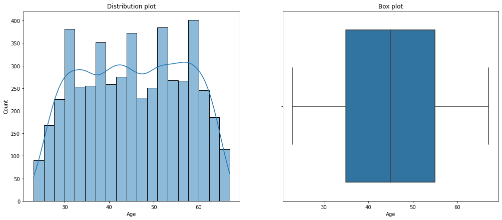

```
 Total Number of outliers in Age: 0
```

```python
f, axes = plt.subplots(1, 2, figsize=(17,7))
sns.boxplot(x = 'Age', data=bank,  orient='h' , ax=axes[1])
sns.histplot(bank['Age'],  ax=axes[0], kde=True)
axes[0].set_title('Distribution plot')
axes[1].set_title('Box plot')
plt.show()
#checking count of outliers.
q25,q75=np.percentile(bank['Age'],25),np.percentile(bank['Age'],75)
IQR=q75-q25
Threshold=IQR*1.5
lower,upper=q25-Threshold,q75+Threshold
Outliers=[i for i in bank['Age'] if i < lower or i > upper]
print('{} Total Number of outliers in Age: {}'.format('\033[1m',len(Outliers)))
```

### - CustomerSince

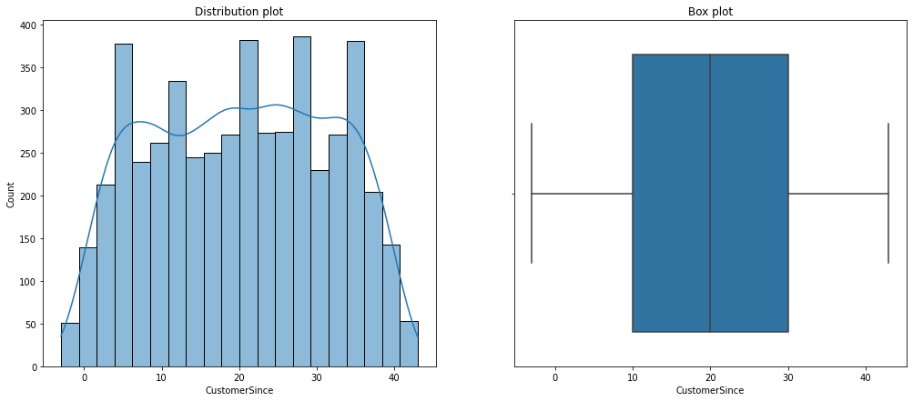

```
 Total Number of outliers in CustomerSince: 0
```

```python
f, axes = plt.subplots(1, 2, figsize=(17,7))
sns.boxplot(x = 'CustomerSince', data=bank,  orient='h' , ax=axes[1])
sns.histplot(bank['CustomerSince'],  ax=axes[0], kde=True)
axes[0].set_title('Distribution plot')
axes[1].set_title('Box plot')
plt.show()
#checking count of outliers.
q25,q75=np.percentile(bank['CustomerSince'],25),np.percentile(bank['CustomerSince'],75)
IQR=q75-q25
Threshold=IQR*1.5
lower,upper=q25-Threshold,q75+Threshold
Outliers=[i for i in bank['CustomerSince'] if i < lower or i > upper]
print('{} Total Number of outliers in CustomerSince: {}'.format('\033[1m',len(Outliers)))
```

#### Most of the people became customer of bank between 10 to 30. Here the units are masked and We have no outliers

### - HighestSpend

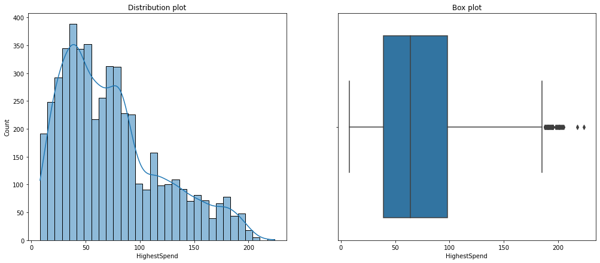

```
 Total Number of outliers in HighestSpend: 96
```

```python
f, axes = plt.subplots(1, 2, figsize=(17,7))
sns.boxplot(x = 'HighestSpend', data=bank,  orient='h' , ax=axes[1])
sns.histplot(bank['HighestSpend'],  ax=axes[0], kde=True)
axes[0].set_title('Distribution plot')
axes[1].set_title('Box plot')
plt.show()
#checking count of outliers.
q25,q75=np.percentile(bank['HighestSpend'],25),np.percentile(bank['HighestSpend'],75)
IQR=q75-q25
Threshold=IQR*1.5
lower,upper=q25-Threshold,q75+Threshold
Outliers=[i for i in bank['HighestSpend'] if i < lower or i > upper]
print('{} Total Number of outliers in HighestSpend: {}'.format('\033[1m',len(Outliers)))
```

###### We can see positive skewness in the data, In one transaction highest spend amount is between 45 to 100. Here the units are masked

###### We can see 96 Outliers! Few customers spent more than 200 as well

### - MonthlyAverageSpend

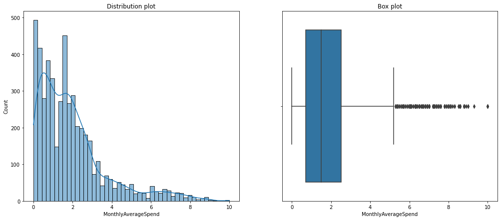

```
 Total Number of outliers in MonthlyAverageSpend: 324
```

```python
f, axes = plt.subplots(1, 2, figsize=(17,7))
sns.boxplot(x = 'MonthlyAverageSpend', data=bank,  orient='h' , ax=axes[1])
sns.histplot(bank['MonthlyAverageSpend'],  ax=axes[0], kde=True)
axes[0].set_title('Distribution plot')
axes[1].set_title('Box plot')
plt.show()
#checking count of outliers.
q25,q75=np.percentile(bank['MonthlyAverageSpend'],25),np.percentile(bank['MonthlyAverageSpend'],75)
IQR=q75-q25
Threshold=IQR*1.5
lower,upper=q25-Threshold,q75+Threshold
Outliers=[i for i in bank['MonthlyAverageSpend'] if i < lower or i > upper]
print('{} Total Number of outliers in MonthlyAverageSpend: {}'.format('\033[1m',len(Outliers)))
```

##### We can see huge positive skewness in the data, Monthly average spend of the customer are mostly between 1 to 3(Units are masked)

##### There is more number of outliers.This tells some customers spent huge amount as well

### - ZipCode

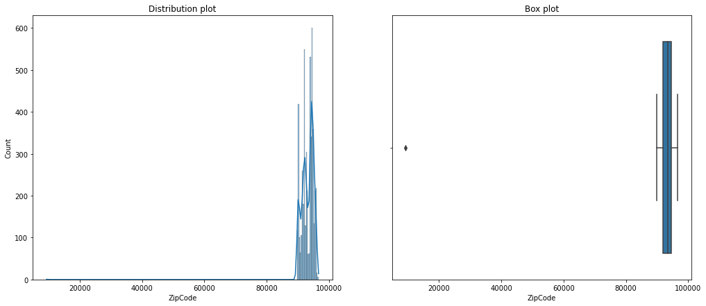

```
 Total Number of outliers in ZipCode: 1
```

```python
f, axes = plt.subplots(1, 2, figsize=(17,7))
sns.boxplot(x = 'ZipCode', data=bank,  orient='h' , ax=axes[1])
sns.histplot(bank['ZipCode'],  ax=axes[0], kde=True)
axes[0].set_title('Distribution plot')
axes[1].set_title('Box plot')
plt.show()
#checking count of outliers.
q25,q75=np.percentile(bank['ZipCode'],25),np.percentile(bank['ZipCode'],75)
IQR=q75-q25
Threshold=IQR*1.5
lower,upper=q25-Threshold,q75+Threshold
Outliers=[i for i in bank['ZipCode'] if i < lower or i > upper]
print('{} Total Number of outliers in ZipCode: {}'.format('\033[1m',len(Outliers)))
```

#### Most of the zipcodes are appeared once. There is no proper distribution, This column does not add value to the model. We will drop during model building

### Mortgage

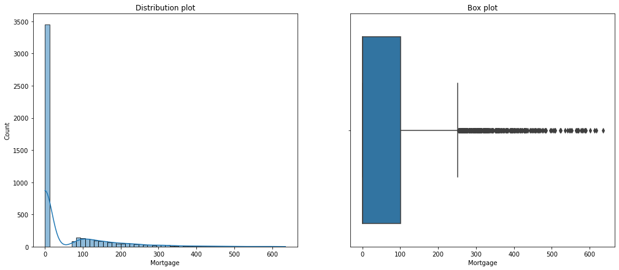

```
 Total Number of outliers in Mortgage: 291
```

```python
f, axes = plt.subplots(1, 2, figsize=(17,7))
sns.boxplot(x = 'Mortgage', data=bank,  orient='h' , ax=axes[1])
sns.histplot(bank['Mortgage'],  ax=axes[0], kde= True)
axes[0].set_title('Distribution plot')
axes[1].set_title('Box plot')
plt.show()
#checking count of outliers.
q25,q75=np.percentile(bank['Mortgage'],25),np.percentile(bank['Mortgage'],75)
IQR=q75-q25
Threshold=IQR*1.5
lower,upper=q25-Threshold,q75+Threshold
Outliers=[i for i in bank['Mortgage'] if i < lower or i > upper]
print('{} Total Number of outliers in Mortgage: {}'.format('\033[1m',len(Outliers)))
```

#### Most of cases we have zero as value this tell most of the cutomer doest have mortage.we can see there is no proper distribution.

### Bi Variate Analysis

#### Numerical vs Categorical

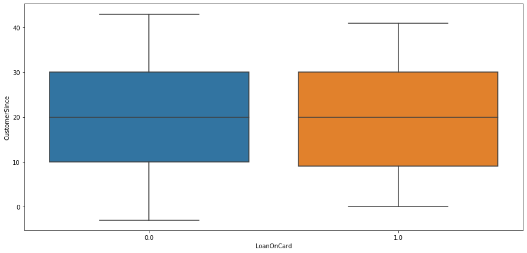

```python
plt.figure(figsize=(15,7))
sns.boxplot(x='LoanOnCard', y='CustomerSince', data= bank)
plt.show()
```

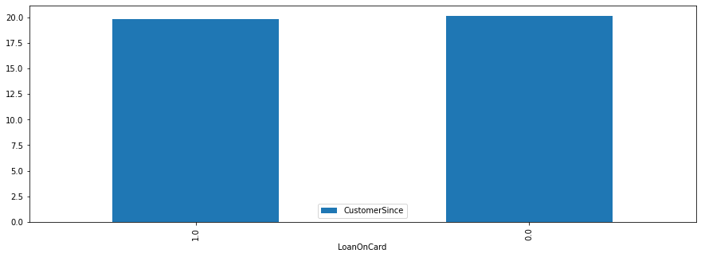

```python
bank.groupby(by=['LoanOnCard'])['CustomerSince'].mean().reset_index().sort_values(['CustomerSince']).tail(10).plot(x='LoanOnCard',y='CustomerSince',kind='bar',figsize=(15,5))
plt.show()
```

###### Mean values are nearly equal for both loan holders and non loan holders

### HighestSpend vs LoanOnCard

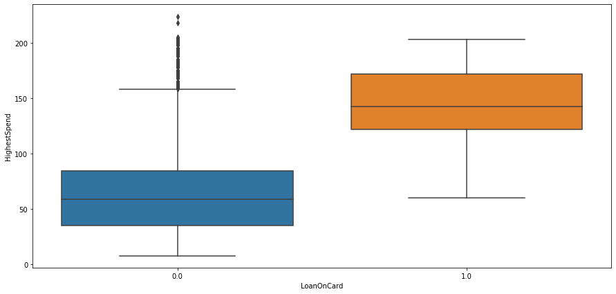

```python
plt.figure(figsize=(15,7))
sns.boxplot(x='LoanOnCard', y='HighestSpend', data= bank)
plt.show()
```

##### Some customer who does not have loan also spends more sometimes !!

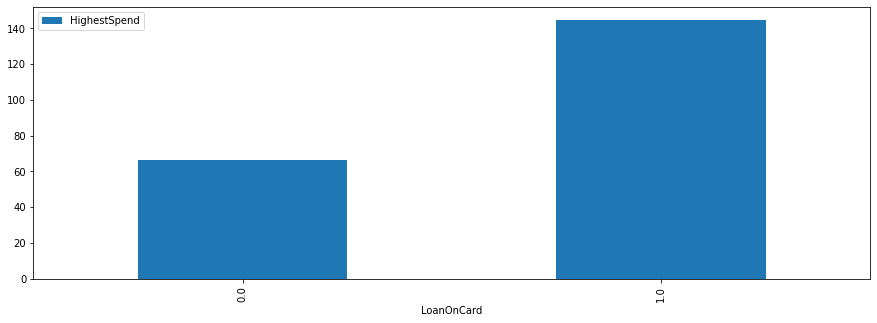

```python
bank.groupby(by=['LoanOnCard'])['HighestSpend'].mean().reset_index().sort_values(['HighestSpend']).tail(10).plot(x='LoanOnCard',y='HighestSpend',kind='bar',figsize=(15,5))
plt.show()
```

##### Mean value of highest spend is more for loan holders

### MonthlyAverageSpend vs LoanOnCard

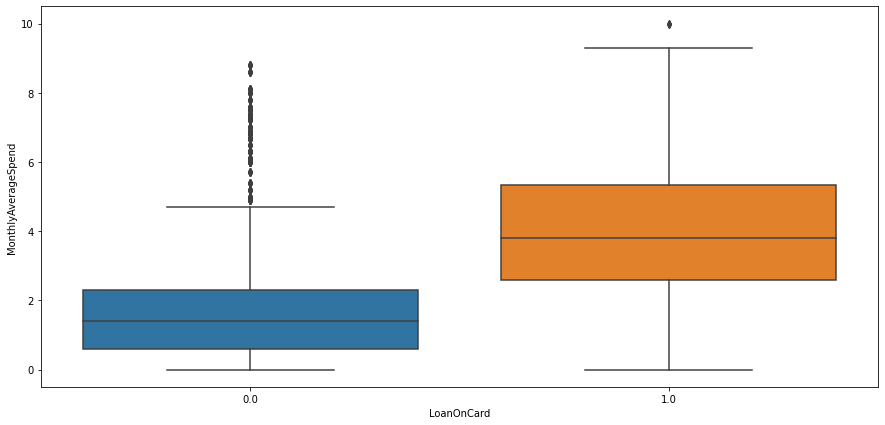

```python
plt.figure(figsize=(15,7))
sns.boxplot(x='LoanOnCard', y='MonthlyAverageSpend', data= bank)
plt.show()
```

#### Monthly average spend is more for loan holders, This column is directly proportional to highest spend

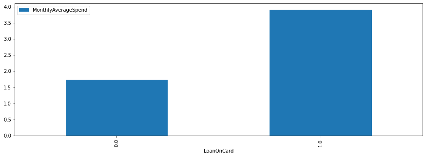

```python
bank.groupby(by=['LoanOnCard'])['MonthlyAverageSpend'].mean().reset_index().sort_values(['MonthlyAverageSpend']).tail(10).plot(x='LoanOnCard',y='MonthlyAverageSpend',kind='bar',figsize=(15,5))
plt.show()
```

#### Mortgage vs LoanOnCard

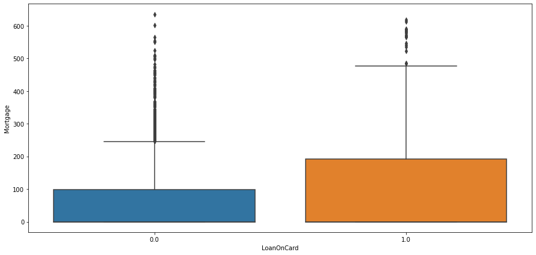

```python
plt.figure(figsize=(15,7))
sns.boxplot(x='LoanOnCard', y='Mortgage', data= bank)
plt.show()
```

##### Mortage value is high for loan holders, We can see extreme value in both the cases

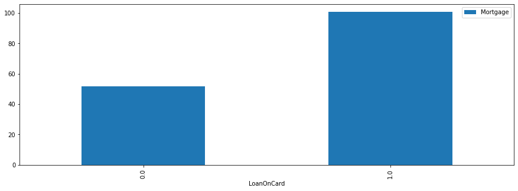

```python
bank.groupby(by=['LoanOnCard'])['Mortgage'].mean().reset_index().sort_values(['Mortgage']).tail(10).plot(x='LoanOnCard',y='Mortgage',kind='bar',figsize=(15,5))
plt.show()
```

##### Mortgage Mean values are more for loan holders

#### Age vs LoanOnCard

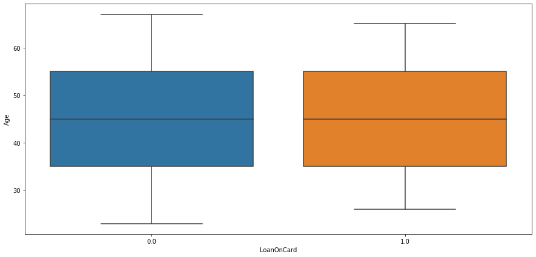

```python
plt.figure(figsize=(15,7))
sns.boxplot(x='LoanOnCard', y='Age', data= bank)
plt.show()
```

### Age distribution is nearly equal for both loan holders and non-loan holders

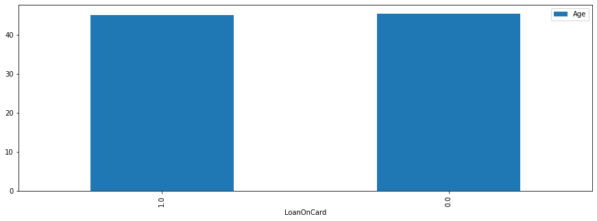

```python
bank.groupby(by=['LoanOnCard'])['Age'].mean().reset_index().sort_values(['Age']).tail(10).plot(x='LoanOnCard',y='Age',kind='bar',figsize=(15,5))
plt.show()
```

#### Mean values are nearly equal so age is not affected for taking loans

## Numerical vs Numerical

#### MonthlyAverageSpend vs HighestSpend

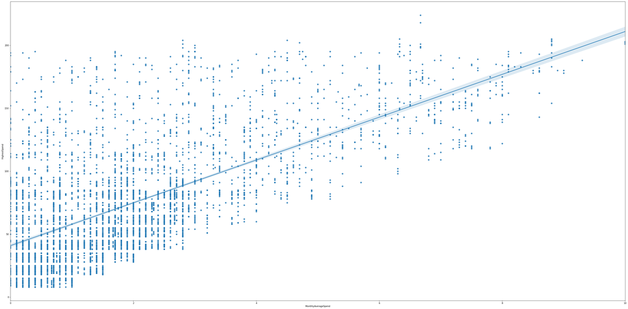

```python
figure = plt.figure(figsize=(50,25))
ax = sns.regplot(x='MonthlyAverageSpend',y='HighestSpend', data=bank)
```

#### There is clear linear relationship between Monthly average spend and highest spend.

### Age vs MonthlyAverageSpend

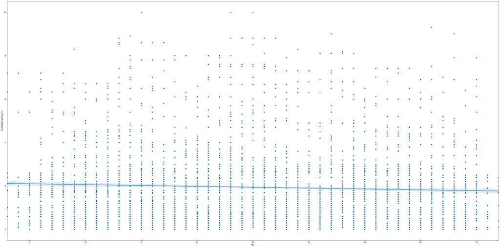

```python
figure = plt.figure(figsize=(50,25))
ax = sns.regplot(x='Age',y='MonthlyAverageSpend', data=bank)
```

##### as anticipated, Age does not have any relationship with spending.

#### CustomerSince vs MonthlyAverageSpend

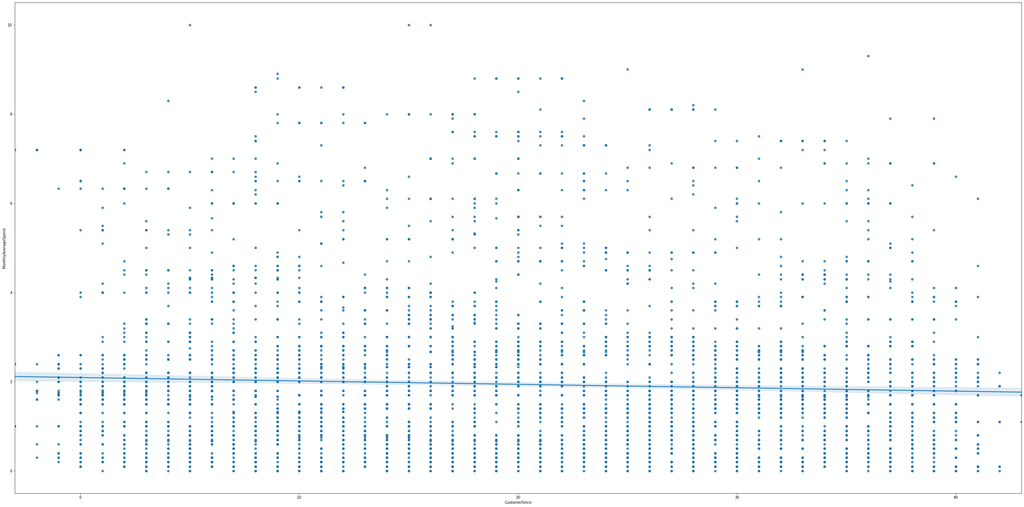

```python
figure = plt.figure(figsize=(50,25))
ax = sns.regplot(x='CustomerSince',y='MonthlyAverageSpend', data=bank)
```

#### Customer period is not dependent on spend

#### Mortgage vs MonthlyAverageSpend

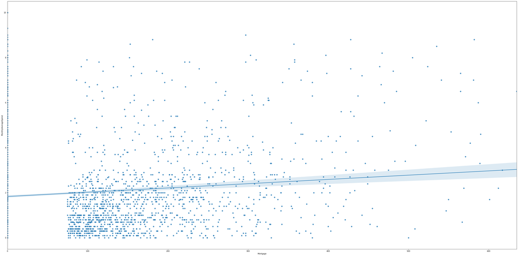

```python
figure = plt.figure(figsize=(50,25))
ax = sns.regplot(x='Mortgage',y='MonthlyAverageSpend', data=bank)
```

##### Mortgage value has slight relationship with spend

### Correlation among pairs of continuous variables

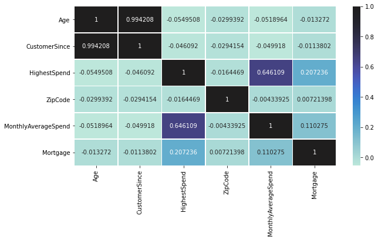

```python
plt.figure(figsize=(10,5))
sns.heatmap(bank.corr(), annot=True, linewidths=.5, fmt= 'g', center = 1 )  # heatmap
plt.show()
```